# Module 3 — Gene Set Analysis

RNA-seq Tutorial: camera and GSEA, From Gene Lists to Biological Programs

Francesco Cecere** · *Senior Bioinformatic Researcher* · AORN Santobono-Pausilipon IRCCS

05 novembre 2026

# From Module 2

Module 2 found thousands of genes changed between the tumors and the normal kidneys of the same children. A list that long cannot be read gene by gene. This module asks a different question: **do the genes of a known biological program move together?**

**Plan:** gene sets → two kinds of test → `camera` (limma) → GSEA (`fgsea`) → do the methods agree? → GO terms with redundancy collapsed.

```r
# Same matrix, sample sheet and paired design as Module 2.
tumor_tpm   <- read_csv("data/TARGET_WT_gene_expression_tpm.csv", show_col_types = FALSE)
control_tpm <- read_csv("data/TARGET_WT_control_gene_expression_tpm.csv", show_col_types = FALSE)
tumor_metadata   <- read_csv("data/sample_metadata.csv", show_col_types = FALSE)
control_metadata <- read_csv("data/TARGET_WT_control_clinical_raw.csv", show_col_types = FALSE)

tpm <- as.matrix(bind_cols(tumor_tpm[, -1], control_tpm[, -1]))
rownames(tpm) <- tumor_tpm$gene_name
samples <- bind_rows(
  tumor_metadata %>% transmute(sample_id = case_submitter_id, patient = case_submitter_id, condition = "Tumor"),
  control_metadata %>% transmute(sample_id = sample_submitter_id, patient = case_submitter_id, condition = "Normal")
) %>%
  mutate(condition = factor(condition, levels = c("Normal", "Tumor")), patient = factor(patient))
samples <- samples[match(colnames(tpm), samples$sample_id), ]
stopifnot(identical(samples$sample_id, colnames(tpm)))

log_expr <- log2(tpm[rowSums(tpm >= 1) >= min(table(samples$condition)), ] + 1)
design_paired <- model.matrix(~ patient + condition, data = samples)

# Module 2's paired results.
limma_results <- read_csv("results/limma_tumor_vs_normal_paired.csv", show_col_types = FALSE)
```

# Part 1 — Gene Sets

A **gene set** is a list of genes sharing a function. We use two collections from **MSigDB**, saved in `data/` by `data-prep/build_gene_sets.R`:

- **Hallmark** (50 sets): compact, curated, non-redundant summaries of well-defined biological states, e.g. `HALLMARK_E2F_TARGETS` (cell-cycle genes switched on by E2F) or `HALLMARK_OXIDATIVE_PHOSPHORYLATION`. The best starting point.
- **GO Biological Process** (thousands of sets): detailed and hierarchical, but highly redundant.

```r
hallmark <- gmtPathways("data/msigdb_hallmark.gmt")
go_bp    <- gmtPathways("data/msigdb_go_bp.gmt")

min_size <- 15
max_size <- 500

pretty_name <- function(x) str_replace_all(str_remove(x, "^(HALLMARK|GOBP)_"), "_", " ")
```

# Part 2 — Two Questions You Can Ask of a Gene Set

|  | **Competitive** test | **Self-contained** test |
| --- | --- | --- |
| question | are the set’s genes *more* changed than the other genes? | are the set’s genes changed *at all*? |
| examples | `camera`, GSEA, ORA | `roast`, `fry` (limma) |
| when tumor vs normal changes thousands of genes | still informative | almost every set is “significant” |

We use **competitive** tests: they tell us which programs stand out *relative to* the general change.

**The hidden problem: genes are correlated.** Genes of one pathway tend to go up and down together across samples. Many gene set tests treat them as independent, which makes them far too confident (p-values much too small). **camera** (*Correlation Adjusted MEan RAnk*) estimates the average correlation between the genes of each set and corrects the test for it. It is limma’s recommended competitive test and works directly on the expression matrix and the design, here the paired one.

# Part 3 — camera

```r
hallmark_index <- ids2indices(hallmark, rownames(log_expr))

# contrast = the coefficient to test, by name: the tumor effect of the paired design.
camera_results <- camera(log_expr, index = hallmark_index, design = design_paired, contrast = "conditionTumor") %>%
  rownames_to_column("pathway") %>%
  as_tibble()
```

camera on the 50 Hallmark sets.

| sets_tested | FDR < 0.05, up in tumor | FDR < 0.05, down in tumor |
| --- | --- | --- |
| 50 | 8 | 30 |

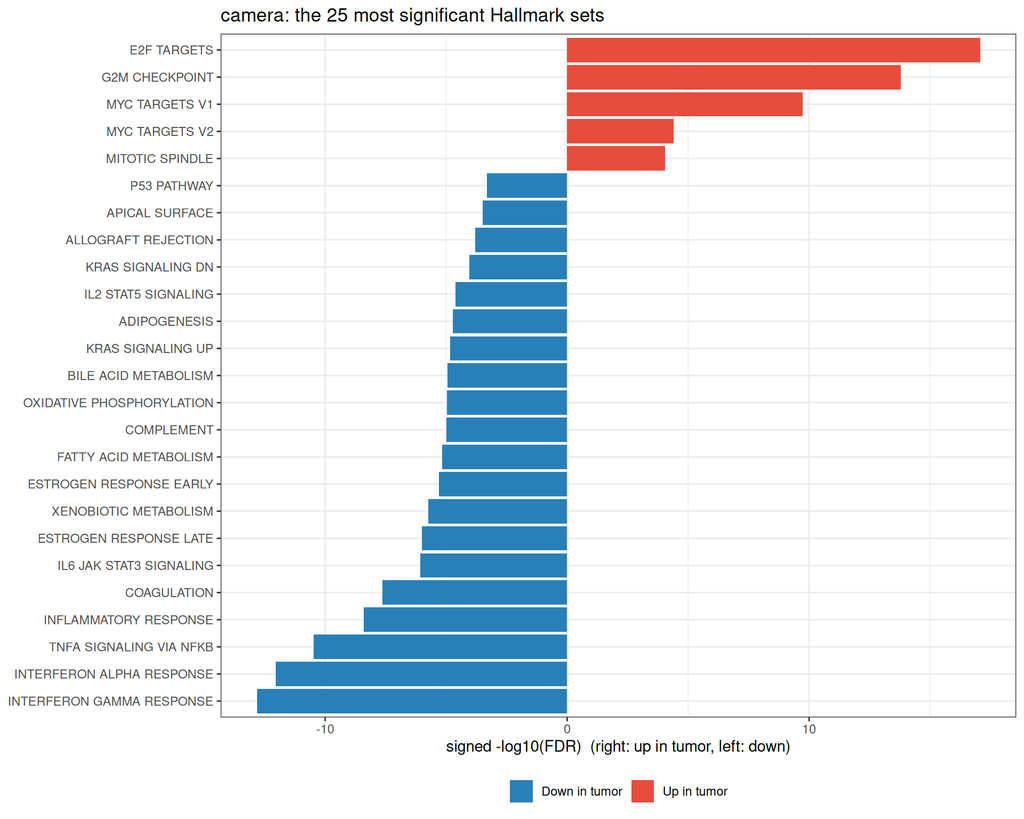

# Part 4 — GSEA with fgsea

**GSEA** ranks all genes from most up to most down and asks whether a set’s genes concentrate at one end of the list. We rank by the **moderated t-statistic** of Module 2 (it combines fold change and precision, and carries the direction).

```r
ranks <- limma_results %>% arrange(desc(t)) %>% pull(t, name = gene)

run_fgsea <- function(gene_sets) {
  set.seed(20261105)
  fgsea(pathways = gene_sets, stats = ranks, minSize = min_size, maxSize = max_size, eps = 0) %>%
    as_tibble() %>% arrange(padj)
}

gsea_hallmark <- run_fgsea(hallmark)
```

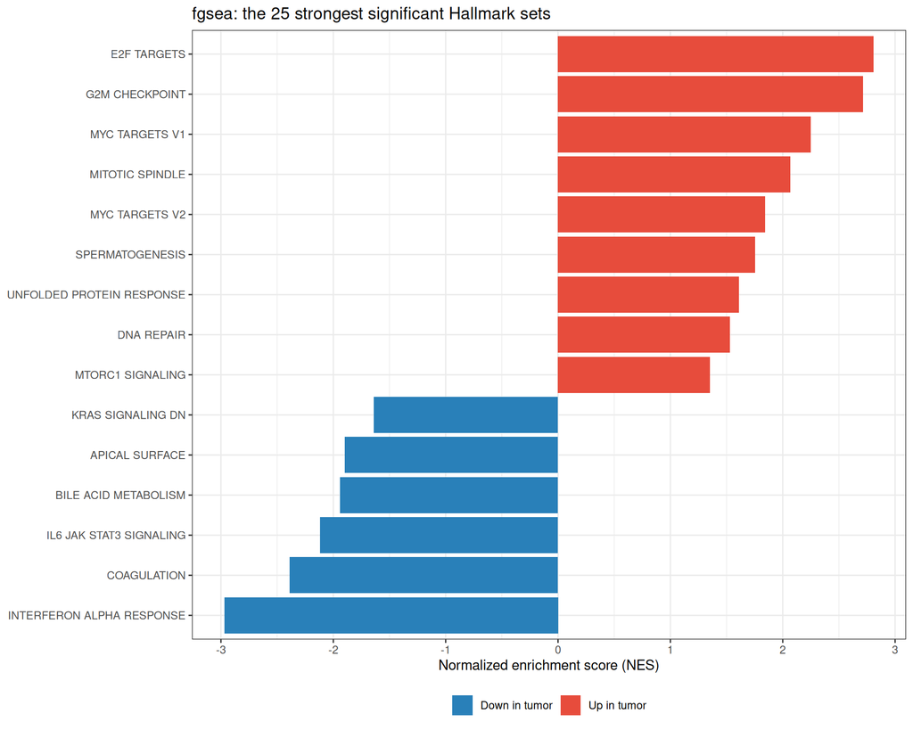

The classic GSEA plot for the strongest set in each direction: the green curve is the running enrichment score, each tick one gene of the set at its rank (left = most up in the tumor). The **leading edge** is the part of the list before the peak: the genes that drive the enrichment.

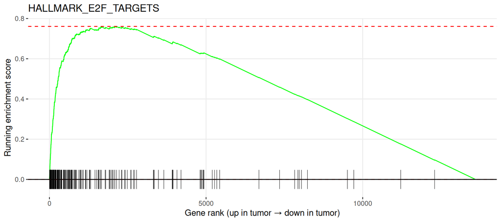

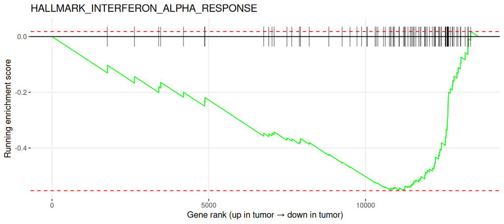

# Part 5 — Do camera and GSEA Agree?

```r
agreement <- camera_results %>%
  transmute(pathway, camera_score = -log10(PValue) * if_else(Direction == "Up", 1, -1)) %>%
  inner_join(gsea_hallmark %>% select(pathway, NES), by = "pathway")
agreement_r <- round(cor(agreement$NES, agreement$camera_score), 2)
```

[figure not shown]

# Part 6 — GO Biological Process: Collapsing Redundancy

GO terms give more specific labels, at the cost of heavy redundancy (“cell cycle”, “mitotic cell cycle”, “cell cycle process”…). `collapsePathways()` keeps only the **independent** signals among the top terms.

```r
gsea_go <- run_fgsea(go_bp)

top_go    <- gsea_go %>% filter(padj < 0.05) %>% slice_min(padj, n = 100, with_ties = FALSE)
# collapsePathways() works on fgsea's own data.table output, not on a tibble.
collapsed <- collapsePathways(data.table::as.data.table(top_go), pathways = go_bp, stats = ranks)
main_go   <- top_go %>% filter(pathway %in% collapsed$mainPathways)
```

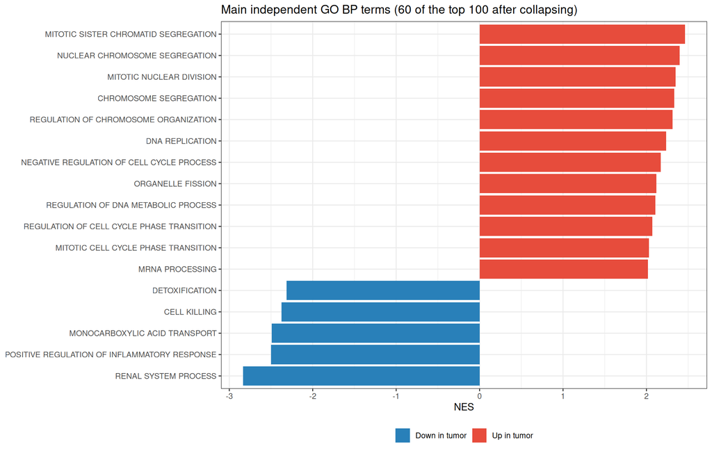

| method | collection | pathway | direction | FDR | NES |
| --- | --- | --- | --- | --- | --- |
| fgsea | GO BP (main terms) | GOBP_CHROMOSOME_SEGREGATION | Up | 3.31e-46 | 2.33 |
| fgsea | GO BP (main terms) | GOBP_NUCLEAR_CHROMOSOME_SEGREGATION | Up | 3.23e-39 | 2.4 |
| fgsea | GO BP (main terms) | GOBP_REGULATION_OF_DNA_METABOLIC_PROCESS | Up | 7.85e-34 | 2.11 |
| fgsea | GO BP (main terms) | GOBP_MITOTIC_NUCLEAR_DIVISION | Up | 3.37e-33 | 2.35 |
| fgsea | GO BP (main terms) | GOBP_ORGANELLE_FISSION | Up | 1.28e-32 | 2.12 |
| fgsea | GO BP (main terms) | GOBP_MITOTIC_SISTER_CHROMATID_SEGREGATION | Up | 1.9e-31 | 2.46 |
| fgsea | GO BP (main terms) | GOBP_DNA_REPLICATION | Up | 3.05e-30 | 2.24 |
| fgsea | GO BP (main terms) | GOBP_REGULATION_OF_CELL_CYCLE_PHASE_TRANSITION | Up | 6.61e-29 | 2.07 |
| fgsea | GO BP (main terms) | GOBP_MRNA_PROCESSING | Up | 1.66e-28 | 2.02 |
| fgsea | GO BP (main terms) | GOBP_REGULATION_OF_CHROMOSOME_ORGANIZATION | Up | 1.94e-28 | 2.31 |

[output cut: 103 more lines]

```r
write_csv(camera_results, "results/camera_hallmark.csv")
bind_rows(Hallmark = gsea_hallmark, `GO BP` = gsea_go, .id = "collection") %>%
  mutate(leadingEdge = map_chr(leadingEdge, ~ paste(.x, collapse = ";"))) %>%
  write_csv("results/fgsea_results.csv")
```

# Part 7 — Reading the Results With Care

- **Up in tumor: proliferation.** Cell-cycle programs (`E2F_TARGETS`, `G2M_CHECKPOINT`, `MYC_TARGETS`) dominate: Wilms tumor is made of dividing embryonic-like cells, while mature kidney cells rarely divide.
- **Down in tumor: what the tumor lacks.** Immune and inflammatory programs (`INTERFERON_GAMMA_RESPONSE`, `TNFA_SIGNALING_VIA_NFKB`, `INFLAMMATORY_RESPONSE`), coagulation and mature metabolic functions describe **which cells are missing** from a tumor sample (resident immune and stromal cells, mature tubule cells) rather than a pathway switched off inside tumor cells. Bulk RNA-seq always mixes cell types.
- **Competitive tests depend on the background.** “Up” means “more up than the typical gene in this comparison”.
- **An enriched set is a hypothesis.** It tells us that the genes of a program move together, not why. The leading-edge genes (in `results/fgsea_results.csv`) are where to look next.

# Summary

- **camera** (limma) is a competitive test that corrects for **inter-gene correlation**, working directly on expression and the paired design.
- **GSEA** (fgsea) ranks all genes by the moderated t-statistic and needs no cutoff.
- Using both, and **collapsing** redundant GO terms, gives a robust, readable picture of the biology behind the DEG list.

Generated on 05 novembre 2026 · Francesco Cecere (Senior Bioinformatic Researcher) · AORN Santobono-Pausilipon IRCCS